# Frederick Solt

##### Income Inequality & Its Consequences, Comparative Political Behavior, and Dynamic Comparative Public Opinion

### SWIID Version 6.1 is available!

Friday, 27 October 2017

Version 6.1 of the SWIID is [now available](http://fsolt.org/swiid/swiid_downloads.html)! Building on the end-to-end revision accomplished in Version 6.0 last July, this new release:

- incorporates in [its source data](https://github.com/fsolt/swiid/blob/master/data/swiid_source.csv) 280 new Ginis, including [newly available LIS data on Canada and Lithuania](http://www.lisdatacenter.org/news-and-events/fall-data-release/);
- includes estimates of disposable income inequality for 83 new country-years;
- expands estimates of market income inequality to *all* country-years (version 6.0 only estimated market income inequality for countries included in the LIS, about a third of the total country-years);
- calculates estimates of absolute and relative redistribution for twenty additional countries, for a total of sixty-six—all of the countries for which there is source data available [on both the distribution of market income and the distribution of disposable income or consumption](http://fsolt.org/blog/2015/10/05/redistribution-observations.html).

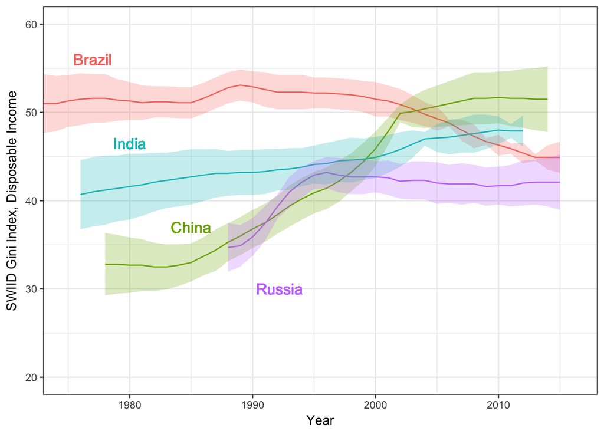

For more details, you can check out the all the R and Stan code used to generate the estimates [in the SWIID GitHub repository](https://github.com/fsolt/swiid). As always, I encourage users of the SWIID to email me with their comments, questions, and suggestions.